# Understanding Chicago's Demographic Characteristics

Matthew Grady

July 10, 2021

### Overview

In this work sample, I'll use R to access and visualize demographic data for the City of Chicago. Here's my plan:

- I'll use the `tidycensus` package to access demographic data from the U.S. Census Bureau's American Community Survey (ACS)<sup>1</sup>;
- I'll use a bar plot to summarize the City's racial composition; and
- I'll create a choropleth map to show how Chicago's largest racial groups are distributed across the city;
- I'll use a diversity index to identify racially diverse, and racially homogeneous neighborhoods; and
- I'll explore diversity in two of Chicago's most diverse community areas: West Ridge and Hyde Park.

Before getting started, I'll load some R packages and some fonts I plan to use.

```r
library(tidyverse)
library(tidycensus)
library(tigris)
library(rgdal)
library(stringr)
library(gridExtra)
library(extrafont)
library(sf)
library(rgeos)
library(ggrepel)
loadfonts(device = "win", quiet = TRUE)
```

### Getting the American Commmunity Survey (ACS) Data

First, I'd like to create a bar plot to show Chicago's racial composition. To do so, I'll access demographic data from the ACS using the `tidycensus` package.

Using the code below, I'll request population estimates, by race, for every census designated place in Illinois. Then, I'll subset data for the City of Chicago. I'll request 2015-2019 five-year estimates, which are based on data collected over a five-year period.

```r
city.dem = get_acs(geography = "place",
              table="B03002",   # The table with the race data
              state = c('IL'),
              survey = 'acs5',  # ACS, 5-year estimates
              year = 2019)

city.dem = city.dem %>%
  filter(NAME %in% c('Chicago city, Illinois'))  # subset Chicago
```

For this analysis, I'll create a new `race` variable by classifying residents into the following mutually exclusive groups:

- White (not Hispanic or Latino)
- Black or African American (not Hispanic or Latino)
- American Indian and Alaska Native (not Hispanic or Latino)
- Asian (not Hispanic or Latino)
- Native Hawaiian and Other Pacific Islander (not Hispanic or Latino)
- Some other race (not Hispanic or Latino)
- Two or more races (not Hispanic or Latino)
- Hispanic or Latino

Going forward, I'll drop the "not Hispanic or Latino" phrase from the group names.

```r
city.dem = city.dem %>%
  filter(variable %in% c('B03002_001','B03002_003','B03002_004','B03002_005',
                         'B03002_006','B03002_007','B03002_008','B03002_009',
                         'B03002_012')) %>%
  mutate(race = as.factor(recode(variable,
    B03002_001="Total",
    B03002_003="White",
    B03002_004="Black or African American",
    B03002_005="American Indian and Alaska Native",
    B03002_006="Asian",
    B03002_007="Native Hawaiian and Other Pacific Islander",
    B03002_008="Some other race",
    B03002_009="Two or more races",
    B03002_012="Hispanic or Latino")
  ))
```

For plotting purposes, I'll retain the groups that make up at least one percent of the Chicago population.

```r
city.dem = city.dem %>%
  mutate(Percent = estimate / estimate[race=='Total']*100) %>%
  filter(Percent >= 1 & race != 'Total')
```

Next, I'll order the levels of the `race` variable based on group size, and create some nicely formatted labels that I'll use when I create the bar plot.

```r
city.dem$race = factor(city.dem$race, levels=c('White','Black or African American','Hispanic or Latino',
                                               'Asian','Two or more races'))

city.dem$labels = paste(as.character(round(city.dem$Percent, 0)), '%', sep='')
```

### Chicago's Racial Distribution

Now, I'm ready to create the bar plot. I'll start by specifying the core sytax for the plot.

```r
bar.plot.dem = ggplot(city.dem, aes(x=race, y=Percent, fill=race)) +
  geom_bar(stat="identity", color='gray70', size=1) +
  scale_fill_manual(values=c('#F8766D','#7CAE00','#C77CFF','#00BFC4','#F564E3')) +
  scale_y_continuous(name=NULL, limits=c(0,40), breaks=seq(0,40,10), expand=c(0,0)) +
  scale_x_discrete(name=NULL, labels=c('White','Black or\nAfrican American','Hispanic or\nLatino',
                                       'Asian','Two or more\nraces')) +
  geom_text(aes(label=labels), vjust=-.5, size=4, family='Segoe UI', color='gray20') +
  labs(title="Chicago has roughly equal numbers of White, Black, and Latinx residents",
       subtitle="Distribution of Race in the City of Chicago",
       caption = "\n\nSource: American Community Survey, 2015-2019 five-year estimates.")
```

Next, I'll make some formatting changes to the plot.

```r
bar.plot.dem = bar.plot.dem +
  theme(
    panel.grid.major = element_blank(),
    panel.grid.minor = element_blank(),
    legend.position = "none",
    plot.title = element_text(size=12, face='bold', hjust=.5, family='Segoe UI'),
    plot.subtitle = element_text(size=12, hjust=.5, family='Segoe UI'),
    plot.caption = element_text(size=9, family='Segoe UI', color='gray30', hjust=0),
    axis.title = element_text(family='Segoe UI'),
    axis.text.y = element_blank(),
    axis.text.x = element_text(family='Segoe UI', size=11),
    axis.ticks = element_blank(),
    panel.background = element_rect(color='gray70', fill='gray94', size=1)
  )
```

I'd like to make a second bar plot that I can set within the first one, to show the ethnic origins for Chicago's Latinx residents. I'll use the `tidycensus` package to get the "origin" data from the ACS.

```r
city.hisp = get_acs(geography = "place",
                    table="B03001",
                    state = c('IL'),
                    year = 2019)

city.hisp = city.hisp %>%
  filter(NAME %in% c('Chicago city, Illinois'))
```

Now, I'll select the five most common ethnic origins to represent in the bar plot.

```r
city.hisp = city.hisp %>%
  filter(variable %in% c('B03001_003','B03001_004','B03001_005','B03001_021',
                         'B03001_010','B03001_006')) %>%
  mutate(origin = as.factor(recode(variable,
                                   B03001_003="Total",
                                   B03001_004='Mexican',
                                   B03001_005='Puerto Rican',
                                   B03001_021='Ecuadorian',
                                   B03001_010='Guatemalan',
                                   B03001_006='Cuban')
  ))
```

Next, I'll get the origin group percentages and do some quick data cleaning.

```r
city.hisp = city.hisp %>%
  mutate(Percent = estimate / estimate[origin=='Total']*100) %>%
  filter(origin != 'Total')

city.hisp = city.hisp[order(city.hisp$estimate),]
city.hisp$origin = factor(city.hisp$origin, levels=city.hisp$origin)
```

Now, I'll create the bar plot of ethnic origin. I'll start by specifying the core syntax for the plot.

```r
city.hisp$labels = paste(as.character(round(city.hisp$Percent, 0)), '%', sep='')

bar.plot.hisp = ggplot(city.hisp, aes(x=origin, y=Percent)) +
  geom_bar(stat="identity", fill='#C77CFF', color='#C77CFF', width=.75) +
  scale_y_continuous(name=NULL, limits=c(0,90), breaks=seq(0,80,10), expand=c(0,0)) +
  scale_x_discrete(name=NULL) +
  geom_text(aes(label=labels), hjust=-.15, size=2.75, family='Segoe UI', color='gray20') +
  coord_flip()
```

Next, I'll make some formatting changes.

```r
bar.plot.hisp = bar.plot.hisp +
  theme(
    plot.margin = margin(5.5, 3, 1, 5.5, "pt"),
    panel.grid.major = element_blank(),
    panel.grid.minor = element_blank(),
    legend.position = "none",
    plot.title = element_text(family='Segoe UI', size=8, face='bold', hjust=0),
    axis.title = element_text(family='Segoe UI'),
    axis.text.y = element_text(family='Segoe UI', size=9),
    axis.text.x = element_blank(),
    axis.ticks = element_blank(),
    panel.background = element_rect(color=NA, fill=NA),
    plot.background = element_rect(fill='gray98', color='gray70', size=1.25)
  )
```

And finally, I'll add one last annotation, and then output the bar plot.

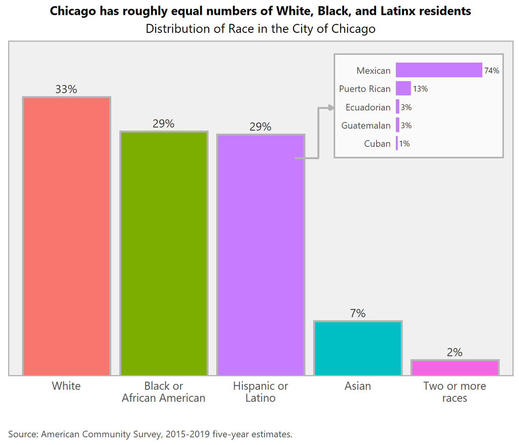

```r
bar.plot.dem = bar.plot.dem +
  geom_segment(aes(x=3.35, y=26, xend=3.6, yend=26), color='gray70', size=1) +
  geom_segment(aes(x=3.59, y=26, xend=3.59, yend=32.1), color='gray70', size=1) +
  geom_segment(aes(x=3.6, y=32, xend=3.75, yend=32), color='gray70', size=1,
               arrow = arrow(length=unit(.015, "npc"), type='closed'))

bar.plot.dem = bar.plot.dem +
  annotation_custom(
    ggplotGrob(bar.plot.hisp),
    xmin=3.75, xmax=5.5, ymin=26, ymax=38.5
  )
bar.plot.dem
```

Next, I'll create a choropleth map that shows how Chicago's largest racial groups are distributed across the city. I'll start by using the `tidycensus` package to get population estimates, by race, for census tracts within the two Illinois counties that overlap with the City of Chicago boundary: Cook and DuPage counties. I'll use the same basic code as before, except that I'll specify "tract" as the desired geographic level.

```r
tract.dem = get_acs(geography = "tract",  # Get tract-level data
              table = "B03002",
              year = 2019,
              survey = 'acs5',
              state = 'IL',
              county = c('Cook','DuPage'))
```

Next, I'll create my own `race` variable in the same way that I did before.

```r
tract.dem = tract.dem %>%
  filter(variable %in% c('B03002_001','B03002_003','B03002_004','B03002_005',
                         'B03002_006','B03002_007','B03002_008','B03002_009',
                         'B03002_012')) %>%
  mutate(race = as.factor(recode(variable,
                                 B03002_001="Total",
                                 B03002_003="White",
                                 B03002_004="Black or African American",
                                 B03002_005="American Indian and Alaska Native",
                                 B03002_006="Asian",
                                 B03002_007="Native Hawaiian and Other Pacific Islander",
                                 B03002_008="Some other race",
                                 B03002_009="Two or more races",
                                 B03002_012="Hispanic or Latino")
  ))
```

Now, I'll calculate each group's share of each census tract's population. Then I'll identify the largest group in each tract. I'll use this information when I create the choropleth map.

```r
tract.dem.largest = tract.dem %>%
  group_by(GEOID) %>%
  mutate(race.pct=estimate / estimate[race=='Total']*100) %>%
  filter(race != 'Total') %>%
  select(GEOID, race, estimate, race.pct) %>%
  slice(which.max(estimate))
```

In order to create the chorpleth map, I need to get census tract shape files for Cook and DuPage counties. I'll access these shape files from the Census Bureau using the `tigris` package.

```r
Cook.tracts = tracts(state = 'IL', county='Cook', cb=F, progress_bar=F, class='sp')
DuPage.tracts = tracts(state = 'IL', county='DuPage', cb=F, progress_bar=F, class='sp')

tracts = rbind(Cook.tracts, DuPage.tracts)
```

The census tract shape files cover the entire area of Cook and DuPage counties. Because I want to limit the map to Chicago only, I'll need to trim the county census tract shape file. To do this, I'll first need to input the Chicago boundary shape file, which I retrieved from the City of Chicago Data Portal<sup>2</sup>.

```r
chi = readOGR("C:/Users/Matt/Desktop/IL shape files/Chicago", "Chicago shape file", verbose=F)
```

Next, I'll change the coordinate reference system for the Chicago shape file. Then, I'll use the `intersect` command from the `raster` package to trim the county census tract shape file along the city boundary.

```r
chi.sf = st_as_sf(chi)
chi.sf = st_transform(chi.sf, "+proj=longlat +ellps=WGS84 +datum=WGS84")
chi = as(chi.sf, 'Spatial')
chi.fort = fortify(chi, region='name') # fortify the shape file

library(raster)
crs(chi) = crs(tracts)
chi.tracts = intersect(tracts, chi)
detach("package:raster", unload=TRUE)
```

Now, I'll limit the data frame with the census tract demographic data to include only tracts that are fully or partially within Chicago. Then, I'll add the demographic data to the census tract shape file. Note that I've also created a fortified version of the shape file, which I'll use to create the choropleth map with `ggplot`.

```r
tract.dem.largest = tract.dem.largest[tract.dem.largest$GEOID %in% chi.tracts$GEOID,]

chi.tracts.fort = fortify(chi.tracts, region='GEOID')

tract.dem.largest$id = tract.dem.largest$GEOID
tr2 = merge(chi.tracts.fort, tract.dem.largest, by='id', all.x=T, all.y=F)
tr2 = tr2[order(tr2$order),]
```

Finally, I'll categorize each tract based on its largest racial group. I'll highlight a tract if its largest group makes up more than 75% of its population. I'll also identify tracts that contain no residents.

```r
tr2$cat3[tr2$race == 'White' & tr2$race.pct >= 75] = 'White >= 75%'
tr2$cat3[tr2$race == 'White' & tr2$race.pct < 75] = 'White < 75%'
tr2$cat3[tr2$race == 'Black or African American' & tr2$race.pct >= 75] = 'Black >= 75%'
tr2$cat3[tr2$race == 'Black or African American' & tr2$race.pct < 75] = 'Black < 75%'
tr2$cat3[tr2$race == 'Hispanic or Latino' & tr2$race.pct >= 75] = 'Latino >= 75%'
tr2$cat3[tr2$race == 'Hispanic or Latino' & tr2$race.pct < 75] = 'Latino < 75%'
tr2$cat3[tr2$race == 'Asian' & tr2$race.pct >= 75] = 'Asian >= 75%'
tr2$cat3[tr2$race == 'Asian' & tr2$race.pct < 75] = 'Asian < 75%'
tr2$cat3[tr2$estimate ==0] = 'No residents'

tr2$cat3 = factor(tr2$cat3, levels=c('White < 75%','White >= 75%','Black < 75%','Black >= 75%',
                                     'Latino < 75%','Latino >= 75%','Asian < 75%','Asian >= 75%','No residents'))
```

Now I'm ready to create the choropleth map. I'll start by specifying the core syntax for the map.

```r
race.map = ggplot() +
  geom_polygon(data=subset(tr2, hole==FALSE),
               aes(x=long, y=lat, group=group, fill=cat3),
               color='gray80', size = 0.05) +
  geom_polygon(data=subset(tr2, hole==TRUE),
               aes(x=long, y=lat, group=group), fill='white',
               color='gray80', size = 0.05) +
  geom_polygon(data=chi.fort,
               aes(x=long, y=lat, group=group),
               color='gray30', size=0.45, fill=NA) +
  scale_fill_manual(values=c(alpha("#F8766D", alpha=.5), "#F8766D", alpha("#7CAE00", alpha=.5), "#7CAE00",
                             alpha("#C77CFF", alpha=.5), "#C77CFF",alpha("#00BFC4", alpha=.5), "#00BFC4", 'gray85'),
                    labels = c('less than 75%','75% or more','less than 75%',
                               '75% or more','less than 75%','75% or more',
                               'less than 75%','75% or more','no residents')) +
  scale_y_continuous(expand=c(0, 0), limits=c(41.64454-.01, 42.02304+.01),
                     breaks=seq(41.6,42.1,.01)) +
  scale_x_continuous(expand=c(0, 0), limits=c(-88.07, -87.39)) +
  labs(title="How are Chicago's largest racial groups distributed across the city?",
       subtitle="Distribution of Race in the City of Chicago, by Census Tract",
       caption = "Source: American Community Survey, 2015-2019 five-year estimates.") +
  guides(fill = guide_legend(ncol=1)) +
  coord_quickmap(clip = 'off')
```

Next, I'll make some formatting changes to the map.

```r
race.map = race.map +
  theme(
    plot.margin=grid::unit(c(7,0,7,0), "pt"),
    legend.position = 'none',
    axis.title = element_blank(),
    axis.text = element_blank(),
    axis.ticks = element_blank(),
    panel.background = element_rect(fill=NA, color=NA),
    plot.background = element_rect(fill='gray97', color='gray65'),
    panel.grid.major = element_blank(),
    panel.grid.minor = element_blank(),
    plot.title = element_text(size=12, face='bold', hjust=.5, family='Segoe UI'),
    plot.subtitle = element_text(size=12, hjust=.5, family='Segoe UI'),
    plot.caption = element_text(size=9, family='Segoe UI', color='gray30', hjust=.95)
  )
```

Now, I'll create a custom legend for the map. The legend will consist of a series of colored rectangles and annotations. I'll start by creating the rectangles.

```r
race.map = race.map +
  geom_rect(mapping=aes(xmin=-87.5, xmax=-87.575, ymin=41.99, ymax=42.00), fill=alpha("#F8766D", alpha=.5),
            color='gray85') +
  geom_rect(mapping=aes(xmin=-87.5, xmax=-87.575, ymin=41.98, ymax=41.99), fill=alpha("#7CAE00", alpha=.5),
            color='gray85') +
  geom_rect(mapping=aes(xmin=-87.5, xmax=-87.575, ymin=41.97, ymax=41.98), fill=alpha("#C77CFF", alpha=.5),
            color='gray85') +
  geom_rect(mapping=aes(xmin=-87.5, xmax=-87.575, ymin=41.96, ymax=41.97), fill=alpha("#00BFC4", alpha=.5),
            color='gray85') +

  geom_rect(mapping=aes(xmin=-87.5, xmax=-87.525, ymin=41.99, ymax=42.00), fill="#F8766D", color='gray85') +
  geom_rect(mapping=aes(xmin=-87.5, xmax=-87.525, ymin=41.98, ymax=41.99), fill="#7CAE00", color='gray85') +
  geom_rect(mapping=aes(xmin=-87.5, xmax=-87.525, ymin=41.97, ymax=41.98), fill="#C77CFF", color='gray85') +
  geom_rect(mapping=aes(xmin=-87.5, xmax=-87.525, ymin=41.96, ymax=41.97), fill="#00BFC4", color='gray85') +
  geom_rect(mapping=aes(xmin=-87.5, xmax=-87.525, ymin=41.92, ymax=41.93), fill="gray85", color='gray60')
```

Now, I'll use some annotations to label the rectangles.

```r
race.map = race.map +
  annotate("text", x=-87.579, y=41.995, hjust='right',
           label = "White", size=3, color='black', family='Segoe UI') +
  annotate("text", x=-87.579, y=41.985, hjust='right',
           label = "Black", size=3, color='black', family='Segoe UI') +
  annotate("text", x=-87.579, y=41.975, hjust='right',
           label = "Latino", size=3, color='black', family='Segoe UI') +
  annotate("text", x=-87.579, y=41.965, hjust='right',
           label = "Asian", size=3, color='black', family='Segoe UI') +
  annotate("text", x=-87.529, y=41.925, hjust='right',
           label = "No residents", size=3, color='black', family='Segoe UI')
```

Next, I'll add a horizontal axis to the legend.

```r
race.map = race.map +
  geom_line(aes(x=c(-87.5, -87.575), y=c(41.958, 41.958)), size=.5) +
  geom_line(aes(x=c(-87.575, -87.575), y=c(41.955, 41.958)), size=.5) +
  geom_line(aes(x=c(-87.525, -87.525), y=c(41.955, 41.958)), size=.5) +
  geom_line(aes(x=c(-87.500, -87.500), y=c(41.955, 41.958)), size=.5) +

  annotate("text", x=-87.575, y=41.954, hjust='center', vjust=1.2,
           label = "25%", size=2.5, color='black', family='Segoe UI') +
  annotate("text", x=-87.525, y=41.954, hjust='center', vjust=1.2,
           label = "75%", size=2.5, color='black', family='Segoe UI') +
  annotate("text", x=-87.500, y=41.954, hjust='center', vjust=1.2,
           label = "100%", size=2.5, color='black', family='Segoe UI')
```

Now, I'll add one final annotation to the map.

```r
race.map = race.map +
  annotate("text", x=-87.55, y=41.857, hjust='left', vjust=.8, family='Segoe UI',
           label = "Census tracts are colored based\non their largest racial group,\nand shaded based on\nthat group's share\nof the population",
           size=3, color='black') +
  geom_curve(aes(xend=-87.597, yend=41.842, x=-87.556, y=41.85), color='black', size=.4, curvature=.2, arrow = arrow(length=unit(.01, "npc"), type='closed'))
```

Chicago is divided into 77 community areas. As a final step, I'd like to overlay the community area boundaries on the map, and label them for reference. I'll start by importing the shape file that contains the community area boundaries. The shape file is from the Chicago Data Portal.

```r
coms = readOGR("C:/Users/Matt/Desktop/Matt/2021-05-31/2. Chicago demographics/Shape files", "geo_export_0fa5b834-5cf4-45b0-ad72-57c2ff4502a8", verbose=F)

coms.sf = st_as_sf(coms)
coms.sf = st_transform(coms.sf, "+proj=longlat +ellps=WGS84 +datum=WGS84")
coms = as(coms.sf, 'Spatial')
coms.fort = fortify(coms, region='community') # fortify the shape file
```

Next, I'll get the centroid for each community area. I'll use the centroids to position labels for the community areas.

```r
centroids = getSpPPolygonsLabptSlots(coms)
coms$X = centroids[,1]
coms$Y = centroids[,2]
cents = data.frame(coms$area_num_1, coms$community, coms$X, coms$Y)
names(cents) = c('Number','Community Area','X','Y')
```

Now, I'll add the community area boundaries to the map, along with the labels. I'll use numbers to label the areas.

```r
race.map = race.map +
  geom_polygon(data=coms.fort,
               aes(x=long, y=lat, group=group),
               color='gray30', size=0.40, fill=NA) +
  geom_text_repel(data=cents, aes(x=X, y=Y, label=Number), size=3, color='gray15',
                  nudge_x=0, nudge_y=-0, direction='y', fontface='bold',
                  bg.colour='white', bg.r=.10, force_pull=1, force=0,
                  lineheight=.80)
```

Next, I'll create a key for the community areas. The key will consist of a table showing the number and name of each community area.

```r
ca.names = cents
ca.names$`Community Area` = tolower(ca.names$`Community Area`)
ca.names$Number = factor(ca.names$Number, levels=seq(1,77,1))
ca.names$Name = paste(ca.names$Number, ca.names$`Community Area`, sep='.  ')
ca.names = ca.names[order(ca.names$Number),]
ca.names = ca.names[, names(ca.names)=='Name']

ca.names = str_to_title(ca.names)
ca.names2 = data.frame(ca.names[1:39], c(ca.names[40:77],''))
```

And finally, I'll add the community area key, and output the map.

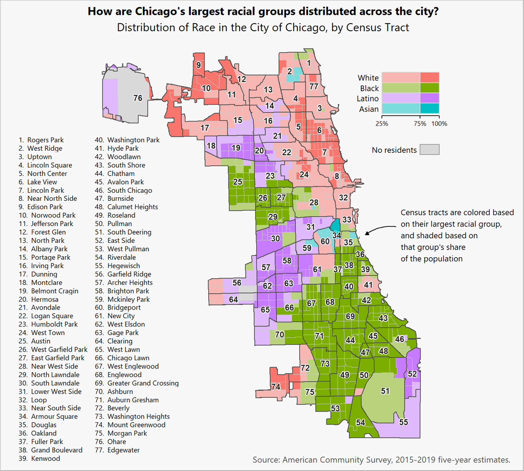

```r
mytheme= ttheme_default(
  core = list(fg_params=list(cex=.64, hjust=0, x=0, fontfamily='Segoe UI'),
              bg_params = list(fill=NA, col=NA)),
  padding = unit(c(2.7, 1.18), "mm"))

ca.table = tableGrob(ca.names2, theme=mytheme, rows=NULL, cols=NULL)

race.map = race.map +
  annotation_custom(ca.table, xmin=-88.10, xmax=-87.78,
                    ymin=41.62, ymax=41.94)

race.map
```

### Exploring Racial Diversity

I'll start by calculating the racial diversity index for each census tract in Cook and DuPage counties. I'll use the same racial categories I established earlier.

```r
tract.dem = tract.dem %>%
  group_by(GEOID) %>%
  mutate(race.pct = estimate / estimate[race=='Total']*100) %>%
  filter(race != 'Total')

tract.div = tract.dem %>%
  group_by(GEOID) %>%
  mutate(race.pct2 = race.pct^2) %>%
  summarize(same = sum(race.pct2),
            same.pct = same / 10000,
            diff.pct = 1-same.pct)
```

Next, I'll limit the data set to include census tracts in the City of Chicago.

```r
tract.div = tract.div[tract.div$GEOID %in% chi.tracts$GEOID,]

tract.div$id = tract.div$GEOID
tr3 = merge(chi.tracts.fort, tract.div, by='id', all.x=T, all.y=F)
tr3 = tr3[order(tr3$order),]
```

Now, I'll categorize the tracts based on the diversity index.

```r
tr3$div.group[round(tr3$diff.pct,2) < .10] = '.00 to .09'
tr3$div.group[round(tr3$diff.pct,2) >= .10 & round(tr3$diff.pct,2) < .20] = '.10 to .19'
tr3$div.group[round(tr3$diff.pct,2) >= .20 & round(tr3$diff.pct,2) < .30] = '.20 to .29'
tr3$div.group[round(tr3$diff.pct,2) >= .30 & round(tr3$diff.pct,2) < .40] = '.30 to .39'
tr3$div.group[round(tr3$diff.pct,2) >= .40 & round(tr3$diff.pct,2) < .50] = '.40 to .49'
tr3$div.group[round(tr3$diff.pct,2) >= .50 & round(tr3$diff.pct,2) < .60] = '.50 to .59'
tr3$div.group[round(tr3$diff.pct,2) >= .60 & round(tr3$diff.pct,2) < .70] = '.60 to .69'
tr3$div.group[round(tr3$diff.pct,2) >= .70 & round(tr3$diff.pct,2) < .80] = '.70 to .79'

tr3$div.group[is.na(tr3$diff.pct) == TRUE] = 'No residents'
```

Now, I'm ready to create the racial diversity choropleth map. I'll start by specifying the core syntax for the map.

```r
div.map = ggplot() +
  geom_polygon(data=subset(tr3, hole==FALSE),
               aes(x=long, y=lat, group=group, fill=div.group),
               color='gray80', size = 0.05) +
  geom_polygon(data=subset(tr3, hole==TRUE),
               aes(x=long, y=lat, group=group), fill='white',
               color='gray80', size = 0.05) +
  geom_polygon(data=chi.fort,
               aes(x=long, y=lat, group=group),
               color='gray30', size=0.45, fill=NA) +
  geom_polygon(data=coms.fort,
               aes(x=long, y=lat, group=group),
               color='gray30', size=0.60, fill=NA) +
  scale_y_continuous(expand=c(0, 0), limits=c(41.64454-.01, 42.02304+.01),
                     breaks=seq(41.6,42.1,.01)) +
  scale_x_continuous(expand=c(0, 0), limits=c(-88.07, -87.39)) +
  scale_fill_manual(values=c('#ffffcc','#ffeda0','#fed976','#feb24c',
                             '#fd8d3c','#fc4e2a','#e31a1c','#b10026','gray85'),
                             name='Racial Diversity') +
  labs(title="Where are Chicago's most racially diverse neighborhoods?",
       subtitle = 'Racial Diversity in the City of Chicago, by Census Tract',
       caption = "Source: American Community Survey, 2015-2019 five-year estimates.") +
  guides(fill = guide_legend(ncol=1)) +
  coord_quickmap(clip = 'off')
```

Next, I'll make some formatting changes to the map.

```r
div.map = div.map +
  theme(
    plot.margin=grid::unit(c(7,0,7,0), "pt"),
    legend.position = c(.85, .76),
    legend.background = element_blank(),
    legend.title = element_text(size=10, face='bold', family='Segoe UI'),
    legend.text = element_text(size=9, family='Segoe UI'),
    axis.title = element_blank(),
    axis.text = element_blank(),
    axis.ticks = element_blank(),
    panel.background = element_rect(fill=NA, color=NA),
    plot.background = element_rect(fill='gray97', color='gray65'),
    panel.grid.major = element_blank(),
    panel.grid.minor = element_blank(),
    plot.title = element_text(size=12, face='bold', hjust=.5, family='Segoe UI'),
    plot.subtitle = element_text(size=12, hjust=.5, family='Segoe UI'),
    plot.caption = element_text(size=9, family='Segoe UI', color='gray30', hjust=.95)
  )
```

Now, I'll add some annotations.

```r
div.map = div.map +
  annotate("text", x=-87.55, y=41.83, hjust='left', vjust=.8, family='Segoe UI',
           label = "The racial diversity index\nrepresents the probability that\ntwo people randomly selected\nfrom the tract will be of\ndifferent races",
           size=3, color='black')

div.map = div.map +
  annotate("text", x=-87.542, y=41.8875, hjust='right', vjust=.8, family='Segoe UI',
           label = "Most\ndiverse", size=3, color='black', lineheight=.9) +
  annotate("text", x=-87.542, y=41.998, hjust='right', vjust=.8, family='Segoe UI',
           label = "Least\ndiverse", size=3, color='black', lineheight=.9)
```

Next, I'll add the labels for the 77 community areas.

```r
div.map = div.map +
  geom_text_repel(data=cents, aes(x=X, y=Y, label=Number), size=3, color='gray15',
                  nudge_x=0, nudge_y=-0, direction='y', fontface='bold',
                  bg.colour='white', bg.r=.10, force_pull=1, force=0,
                  lineheight=.80)
```

And finally, I'll add the key for the commmunity areas, and output the map.

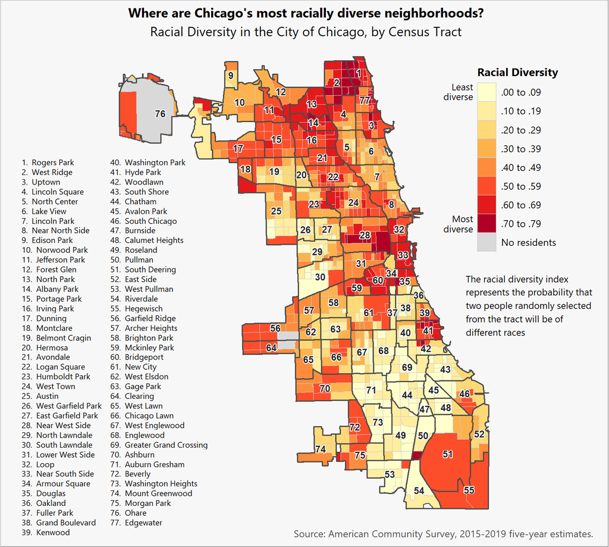

```r
div.map = div.map +
  annotation_custom(ca.table, xmin=-88.10, xmax=-87.78,
                    ymin=41.62, ymax=41.94)

div.map
```

```r
wr.tract.ids = c('17031020200','17031020100','17031020301',
              '17031020302','17031020400','17031020601','17031020602',
              '17031020500','17031020702','17031020802','17031020901',
              '17031020902','17031020701','17031020801')

hp.tract.ids = c('17031836300','17031410200','17031410100','17031410500',
                 '17031410600','17031410700','17031410800','17031410900',
                 '17031836200','17031411200','17031411100','17031411000')
```

Now, I'll use the ACS data to identify the racial distributions for West Ridge and Hyde Park.

```r
div.tract.dem = tract.dem[tract.dem$GEOID %in% wr.tract.ids |
                           tract.dem$GEOID %in% hp.tract.ids,]

div.tract.dem$neighborhood = ifelse(div.tract.dem$GEOID %in% wr.tract.ids, 'West Ridge','Hyde Park')

div.dem = div.tract.dem %>%
  group_by(neighborhood, race) %>%
  summarize(Sum = sum(estimate)) %>%
  mutate(pct = Sum / sum(Sum)*100) %>%
  filter(pct >= 1)
```

Next, I'll do some quick data cleaning and create some labels for the bar plot.

```r
div.dem$race = factor(div.dem$race, levels=c('White','Black or African American','Asian',
                                             'Hispanic or Latino','Two or more races'))

div.dem$labels = paste(as.character(round(div.dem$pct, 0)), '%', sep='')
```

Now, I'll specify the core syntax for the bar plot.

```r
bar.plot.div = ggplot(div.dem, aes(x=race, y=pct, fill=neighborhood)) +
  geom_bar(stat="identity", position='dodge', color='gray70', size=1) +
  scale_fill_manual(values=c("#00B0F6", '#FF62BC')) +
  scale_y_continuous(name=NULL, limits=c(0,52), breaks=seq(0,50,10), expand=c(0,0)) +
  scale_x_discrete(name=NULL, labels=c('White','Black or\nAfrican American','Asian',
                                       'Hispanic or\nLatino','Two or more\nraces')) +
  geom_text(aes(label=labels), position=position_dodge(.9),
            vjust=-.5, size=4, family='Segoe UI', color='gray20') +
  guides(fill = guide_legend(nrow = 1)) +
  labs(title="West Ridge and Hyde Park are two of Chicago's most racially diverse neighborhoods",
       subtitle="Distribution of Race in Chicago's West Ridge and Hyde Park Community Areas",
       caption = "\n\nSource: American Community Survey, 2015-2019 five-year estimates.")
```

Next, I'll make some formatting changes to the plot.

```r
bar.plot.div = bar.plot.div +
  theme(
    panel.grid.major = element_blank(),
    panel.grid.minor = element_blank(),
    legend.position = c(.47, .95),
    legend.title = element_blank(),
    legend.background = element_blank(),
    legend.text = element_text(size=10, family='Segoe UI'),
    plot.title = element_text(size=12, face='bold', hjust=.5, family='Segoe UI'),
    plot.subtitle = element_text(size=12, hjust=.5, family='Segoe UI'),
    plot.caption = element_text(size=9, family='Segoe UI', color='gray30', hjust=0),
    axis.title = element_text(family='Segoe UI'),
    axis.text.y = element_blank(),
    axis.text.x = element_text(family='Segoe UI', size=11),
    axis.ticks = element_blank(),
    panel.background = element_rect(color='gray70', fill='gray94', size=1)
  )
```

Now, I'll create a map that I can set within the bar plot, to show where the West Ridge and Hyde Park community areas are located. I'll start by identifying the census tracts that make up the two community areas.

```r
tr2$neighborhood[tr2$id %in% wr.tract.ids] = 'West Ridge'
tr2$neighborhood[tr2$id %in% hp.tract.ids] = 'Hyde Park'
tr2$neighborhood[! tr2$id %in% hp.tract.ids & ! tr2$id %in% wr.tract.ids] = 'Other'

tr2$neighborhood = factor(tr2$neighborhood, levels=c('Hyde Park','West Ridge','Other'))

div.shapes = coms.fort[coms.fort$id %in% c('HYDE PARK','WEST RIDGE'),]
```

Next, I'll specify the core syntax for the map.

```r
inset.map = ggplot() +
  geom_polygon(data=tr2, aes(x=long, y=lat, group=group, fill=neighborhood),
               color='white', size=0.02) +
  scale_fill_manual(values=c("#00B0F6", '#FF62BC', "gray89")) +
  geom_polygon(data=chi.fort,
               aes(x=long, y=lat, group=group),
               color='gray40', size=0.05, fill=NA) +
  geom_polygon(data=div.shapes, aes(x=long, y=lat, group=group),
               color='gray40', size=0.2, fill=NA) +
  scale_y_continuous(expand=c(0, 0), limits=c(41.64454-.01, 42.02304+.01)) +
  annotate("text", x=-87.53, y=41.843, hjust='center',
           label = "Hyde\nPark", lineheight=.9,
           size=2.25, color='gray20', family='Segoe UI') +
  geom_segment(aes(x=-87.53, y=41.795, xend=-87.565, yend=41.795),
               color='gray20', arrow=arrow(length=unit(.028, "npc"), type='closed')) +
  geom_segment(aes(x=-87.53, y=41.795, xend=-87.53, yend=41.82),
               color='gray20') +
  annotate("text", x=-87.60, y=42.01, hjust='left',
           label = "West\nRidge", lineheight=.9,
           size=2.25, color='gray20', family='Segoe UI') +
  geom_segment(aes(x=-87.61, y=42.01, xend=-87.67, yend=42.01),
               color='gray20', arrow=arrow(length=unit(.028, "npc"), type='closed')) +
  coord_quickmap()
```

Now, I'll make some formatting changes to the map.

```r
inset.map = inset.map +
  theme(
    axis.title = element_blank(),
    axis.text = element_blank(),
    axis.ticks = element_blank(),
    panel.background = element_rect(fill='white'),
    panel.grid.major = element_line(color='white'),
    plot.background = element_rect(fill='gray98', color='gray70', size=1.25),
    legend.title = element_text(size=9, family='Segoe UI'),
    legend.background = element_rect(color=NA, fill=NA),
    legend.position = "none"
  )
```

And finally, I'll output the bar plot with the map set within it.

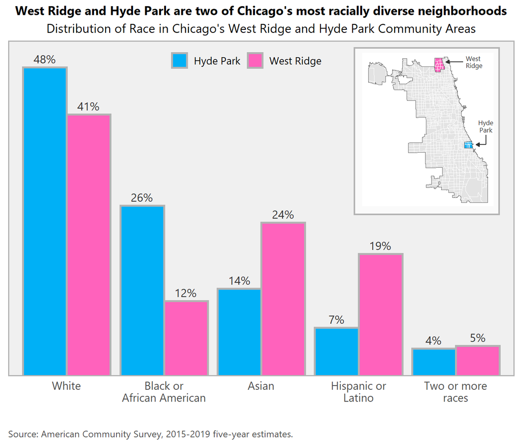

```r
bar.plot.div = bar.plot.div +
  annotation_custom(
    ggplotGrob(inset.map),
    xmin=3.9, xmax=5.5, ymin=25, ymax=51
  )
bar.plot.div
```

### References

<sup>1</sup>U.S. Census Bureau. (2021). 2015-2019 American Community Survey 5-year Public Use Microdata Samples.

<sup>2</sup>Chicago Data Portal, https://data.cityofchicago.org/.